# Patch risk curves and -table

### Patching the curves and the risk table

The final step is done using `patchwork` once again. To put one plot-object (of `ggplot`-type) on top of another simply write them separated by a forward slash (`/`). Put `pip` on top of `risktable`

**Solution**

```r
pip / risktable
```

**Show plot**

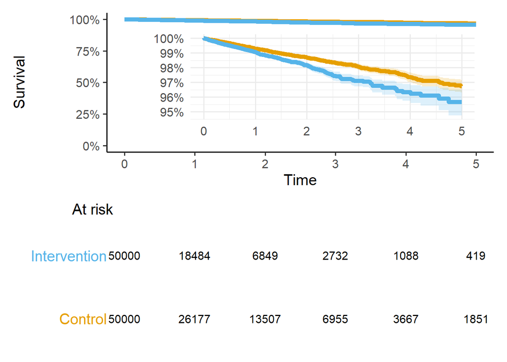

#### Specifying relative heights of plots

This does not look particularly good. We need the curves to make up most of the figure. We can set the relative heights between different rows using the function `plot_layout()`. Add `plot_layout()` with the parameter `heights` specified as a numerical vector with the same length as there are rows in the plot (in this case 2). The numerical values do not have to add up to 1 / 100%. If the values are `x` and `1` then the height of the first row will be `x` times the height of the second. When you are happy with the plot make it an object called `pipatrisk`.

**Solution**

```r
pipatrisk <- pip / risktable + plot_layout(heights = c(9,1))
```

**Show plot**

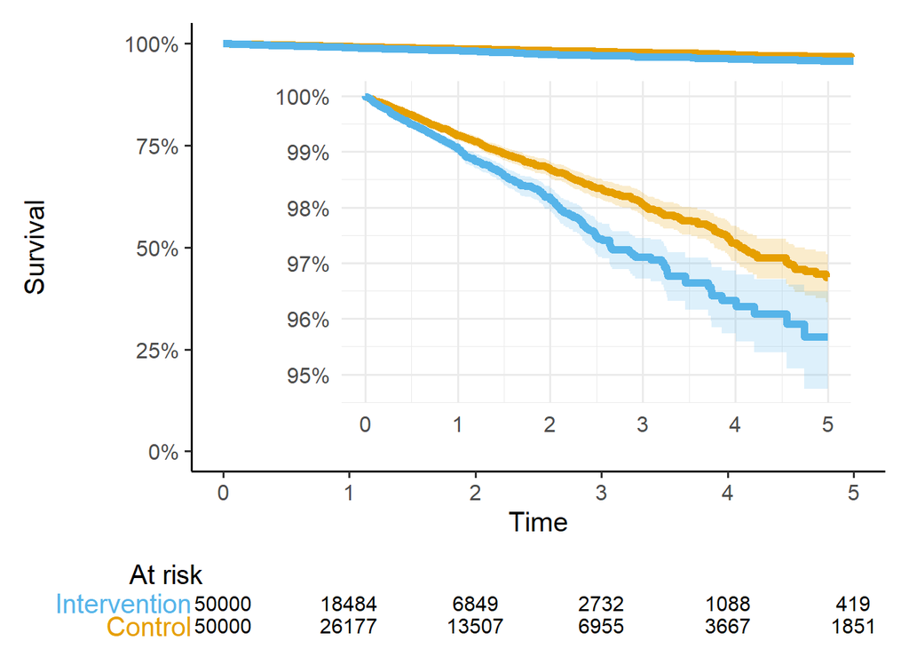